# Отчет по лабораторной работе №3

## Проверяем синтаксис, запускаем службу ddns и проверяем статус.

[figure not shown]

Проверка и запуск kea-dhcp-ddns

## Включаем `enable-updates` в `/etc/kea/kea-dhcp4.conf`.

[figure not shown]

Правка kea-dhcp4.conf (enable-updates)

## Проверяем и перезапускаем DHCP-сервер.

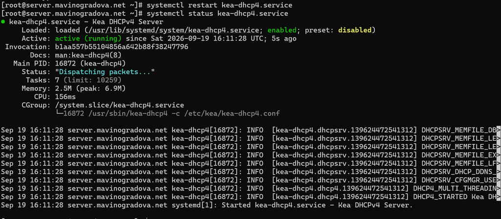

Проверка и перезапуск kea-dhcp4

## На машине client переполучаем адрес.

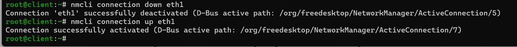

Переполучение адреса на клиенте

## Появление файла `mavinogradova.net.jnl` в каталоге прямой зоны.

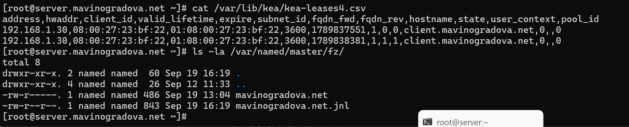

Появление mavinogradova.net.jnl

# Анализ работы DHCP-сервера после настройки DDNS

## Убеждаемся в наличии DNS-записи о клиенте через dig.

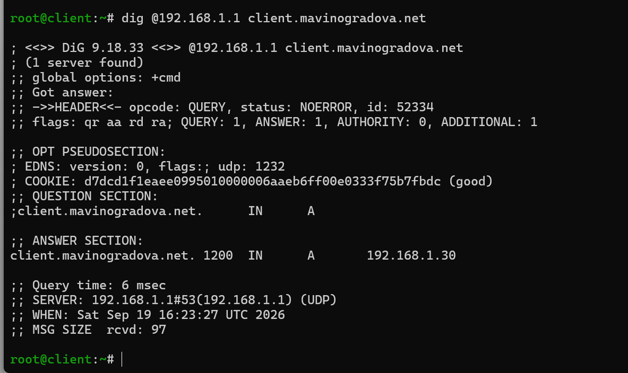

Проверка DNS-записи клиента через dig

# Внесение изменений в настройки внутреннего окружения

## Копируем конфигурационные файлы DHCP в каталог provision.

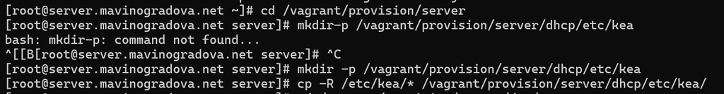

Копирование конфигурационных файлов DHCP

## Копируем конфигурационные файлы DNS-сервера.

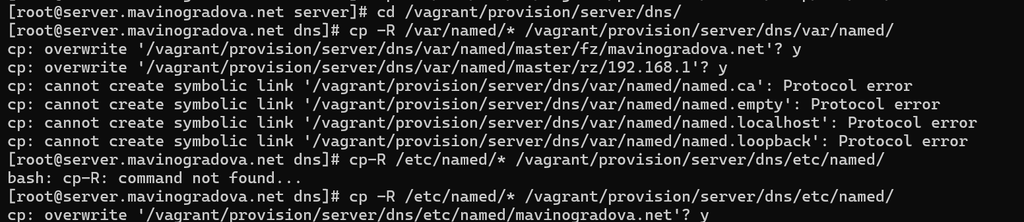

Копирование конфигурационных файлов DNS

## Создаём исполняемый файл `dhcp.sh`.

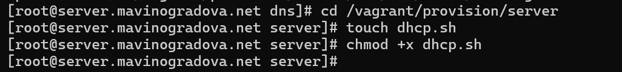

Создание dhcp.sh

## Прописываем в нём скрипт для Vagrant.

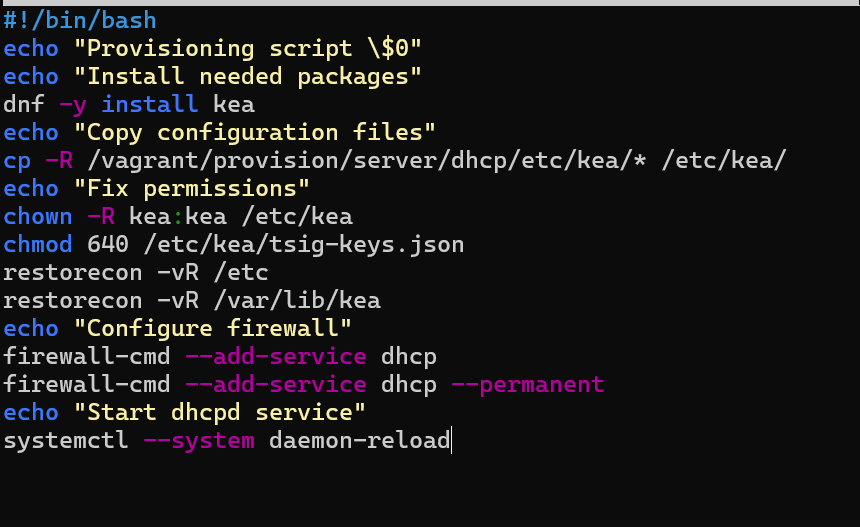

Содержимое dhcp.sh

## Добавляем строку `server.vm.provision "server dhcp"` в `Vagrantfile`.

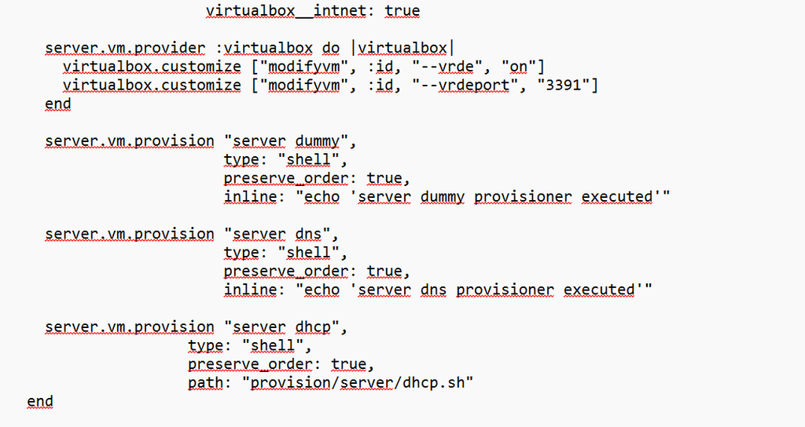

Фрагмент Vagrantfile с server dhcp

## После этого виртуальные машины можно выключить.

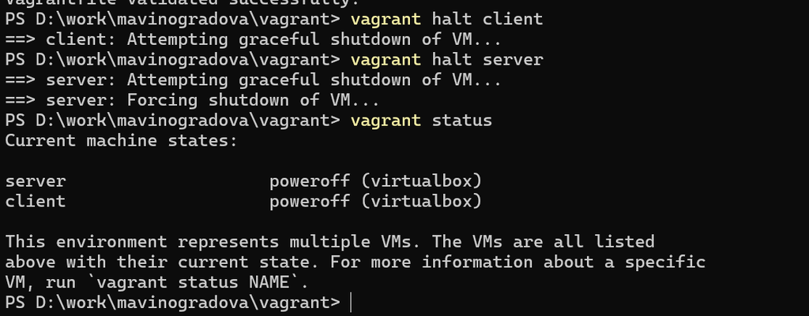

Выключение виртуальных машин

# Выводы

Приобретены практические навыки по установке и конфигурированию DHCP-сервера.

На виртуальной машине server:

- установлен DHCP-сервер Kea;
- настроена выдача адресов из пула `192.168.1.30–199` для виртуальной внутренней сети;
- выполнена привязка службы к интерфейсу `eth1`;
- виртуальная машина client получила IP-адрес `192.168.1.30` по DHCP, что подтверждено утилитами `ifconfig` и файлом аренд `/var/lib/kea/kea-leases4.csv`;
- настроено обновление DNS-зон при появлении новых узлов: сгенерирован TSIG-ключ `DHCP_UPDATE`, разрешено обновление зон в конфигурации `named`, сформирован файл `tsig-keys.json`, сконфигурирован сервис `kea-dhcp-ddns` и включён параметр `enable-updates` в `kea-dhcp4.conf`;
- корректность работы проверена утилитой `dig` — A-запись `client.mavinogradova.net` автоматически создана в прямой зоне;
- написан скрипт `dhcp.sh` для Vagrant, фиксирующий действия по установке и настройке DHCP-сервера, и внесены соответствующие изменения в `Vagrantfile`.